# Project 2: A report on the social links of a courseclassroom

Network visualisation project

Valentin Monney

2021-03-19

# Introduction

This is my second project on data visualization and communication. This time we will try to visualize an undirected network of social ties in a classroom. Let’s do it !

# Part 1: A first impression of the Network

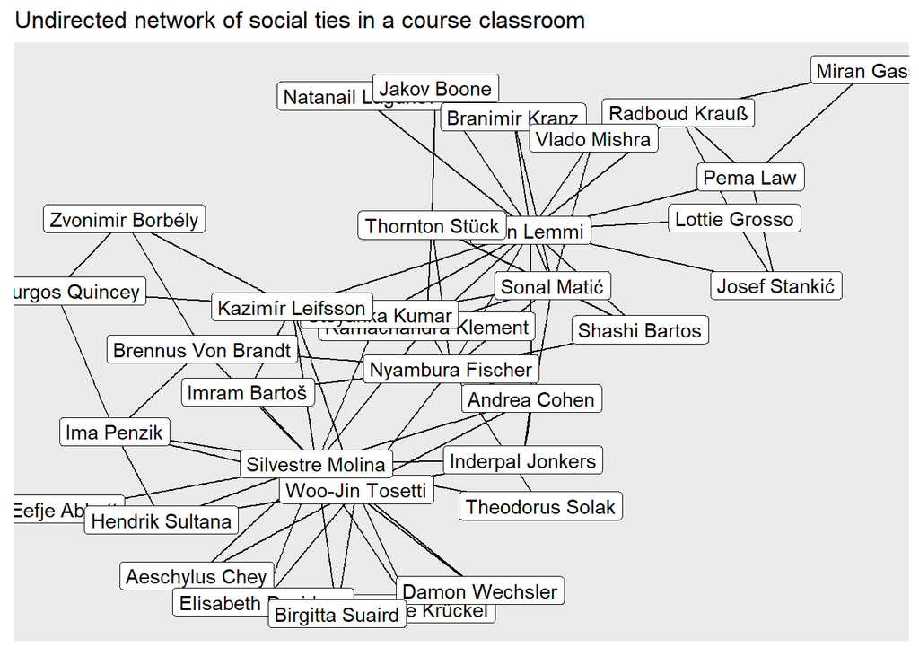

Here is the first result. It’s not too bad, but the labels overlap. Moreover, we don’t need to have the full names, since we can assume that they all know each other in this class. Let’s try to keep only the first name.

# Part 2: Network customization

To clean up the data, it is easier to take the raw data in *tibble* format, make the changes and then transform them back into a *tbl_graph* format. Here is the result with the name separation.

| id | first_name | last_name |
| --- | --- | --- |
| 1 | Rain | Lemmi |
| 2 | Sonal | Matic |
| 3 | Nyambura | Fischer |
| 4 | Thornton | Stück |
| 5 | Lottie | Grosso |
| 6 | Pema | Law |

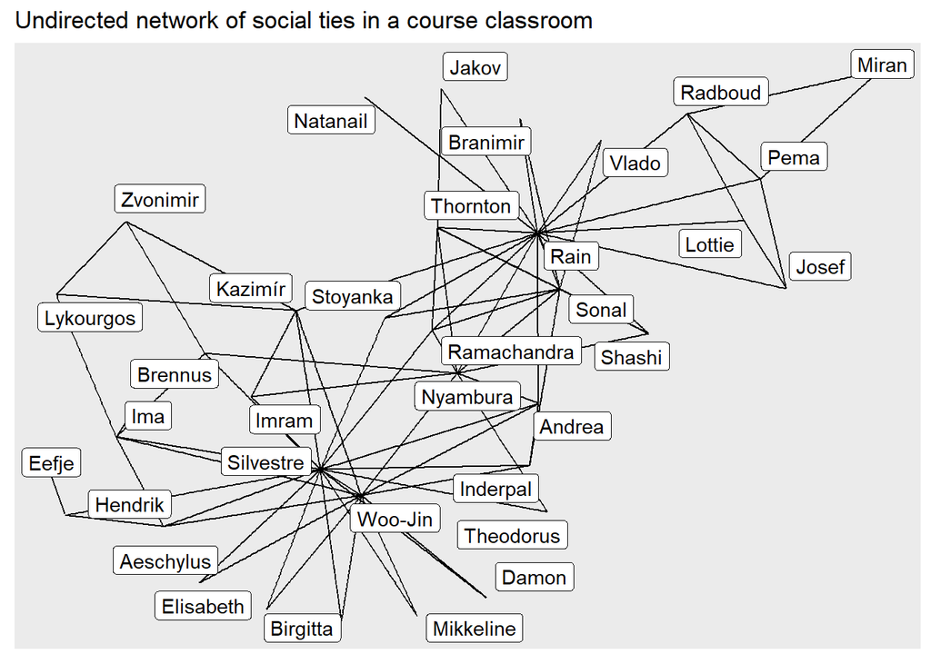

At first glance we see that Silvestre, Woo-Jin and Rain are very well connected while Miran is rather on the edge compared the rest of the class. Let’s see who has the most connections with the *igraph* package.

# Part 3: Well-connected People

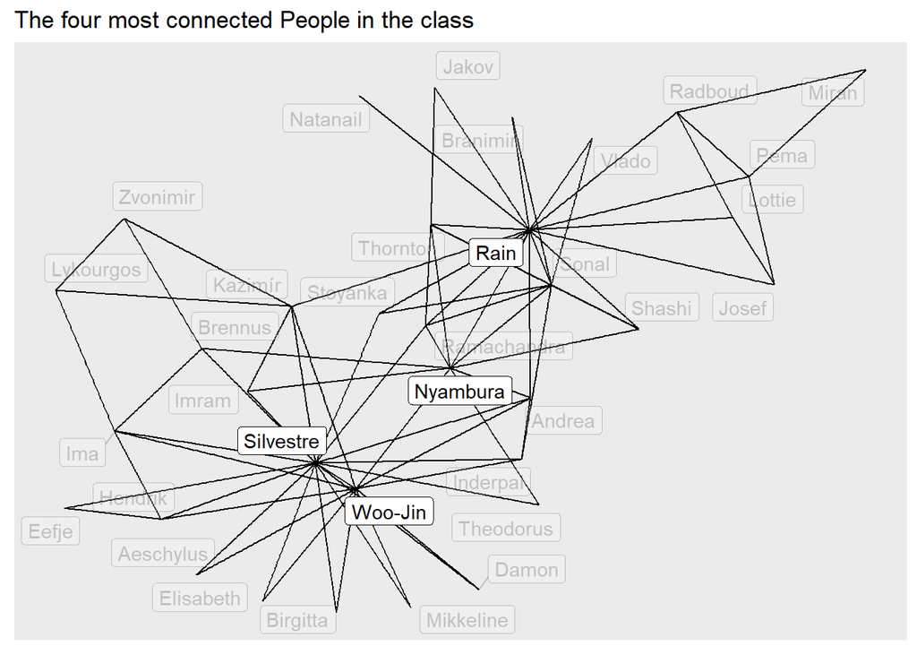

The tree clearly shows that the most popular people are: **Silvestre, Rain, Woo-Jin and Nyambura** with respectively **17, 16, 12 and 10** connections.

# Part 4 : Well-connected People (2)

I’m not really interested in other people’s names. Let’s try to remove their names and put a point instead.

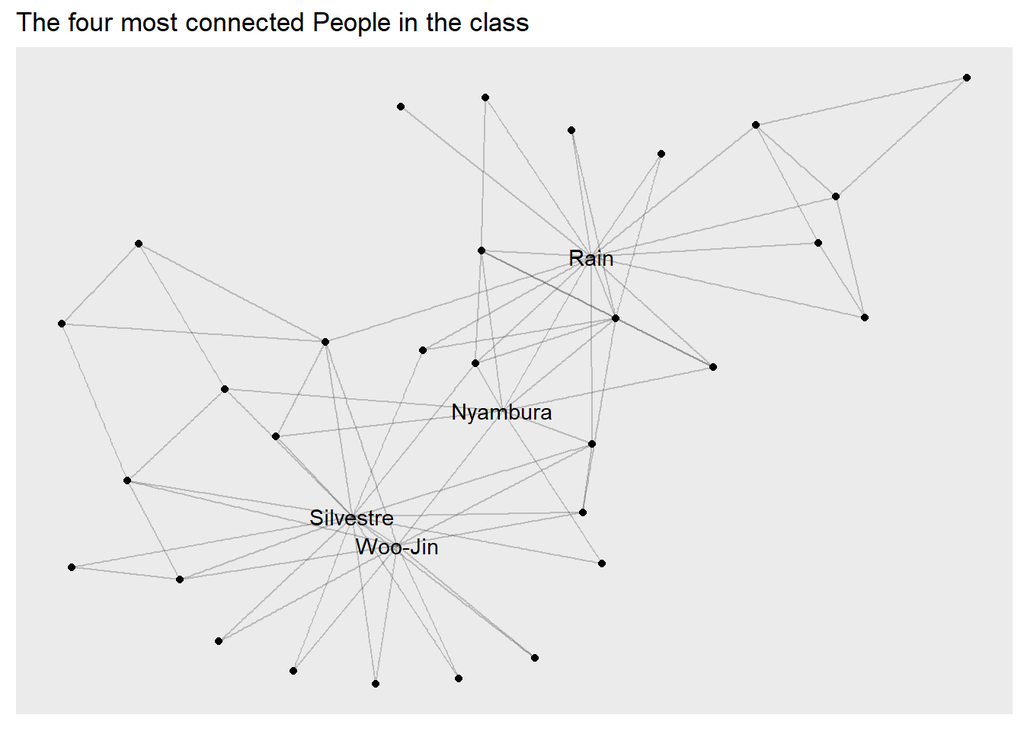

# Part 5: Colour the graph

Now I will color each edge according to the person it is coming from as well as the name.

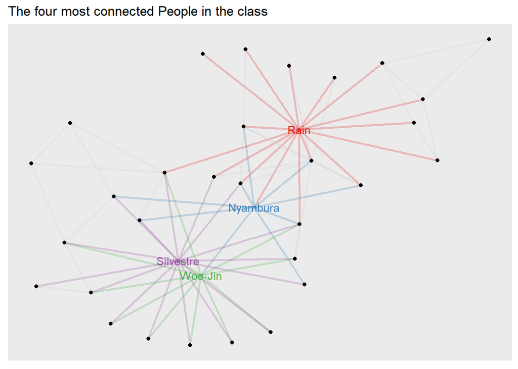

# Part 6: Polishing up

Let’s try to improve our graph a little more. We will remove all text that is not necessary. Instead, we will add a caption and a legend with expressive labels.

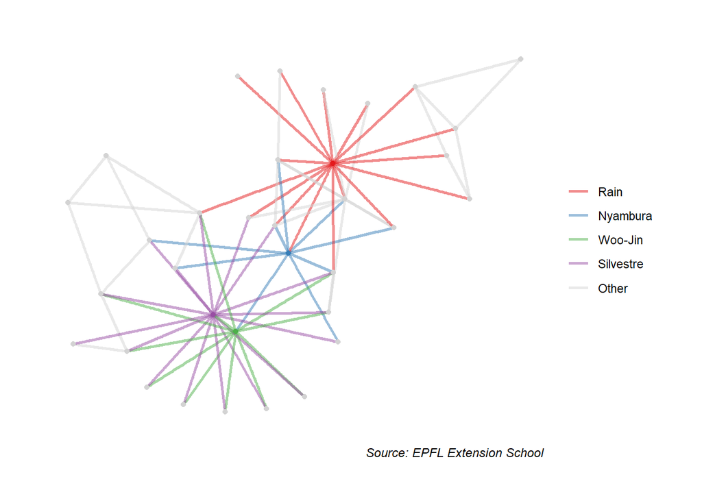